# Cyclistic Analysis

Dhandi Yudhit Yuniar

2023-08-20

**Studi kasus ini dikerjakan untuk menyelesaikan tugas Capstone Project in Google Data Analytics Certificate - [Coursera](https://www.coursera.org/programs/proa-analitik-data-google-o8klv/professional-certificates/analitik-data-google?collectionId=skill~data-analysis)**

#### **Latar Belakang**

Cyclistic merupakan sebuah perusahaan fiksi yang bergerak dibidang penyewaan/berbagi sepeda di Chicago, memiliki 5.824 armada sepeda dan 692 stasiun di seluruh Chicago. Cyclistic menawarkan tiket sekali jalan, tiket sehari penuh, dan keanggotaan tahunan. Pelanggan yang membeli tiket sekali jalan atau tiket sehari penuh disebut sebagai pengendara kasual. Pelanggan yang membeli keanggotaan tahunan adalah anggota tahunan.

Saya adalah seorang analis data junior yang bekerja di tim analis pemasaran di Cyclistic. Direktur pemasaran percaya bahwa kesuksesan perusahaan di masa depan tergantung pada upaya untuk **memaksimalkan jumlah keanggotaan tahunan**. Oleh karena itu, tim saya ingin memahami bagaimana pengendara kasual dan anggota tahunan menggunakan sepeda Cyclistic secara berbeda. Dari wawasan ini, tim saya akan merancang strategi pemasaran baru untuk mengubah pengendara biasa menjadi anggota tahunan.

Dalam menyelesaikan tugas bisnis yang diberikan, saya menggunakan **bahasa pemrograman R** dan kerangka kerja yang telah saya pelajari di Coursera sebagai Data Analysis.

#### **Kerangka Kerja**

Proses Analisi Data

Tugas

**Bertanya**

Pemahaman tentang projek dan ekspektasi pemangku kepentingan

1. Membuat dokumen lingkup kerja (SOW)
2. Mendefinisikan tujuan projek dan ekspektasi pemangku kepentingan
3. Membuat pertanyaan yang menjawab tujuan projek

**Persiapan**

Mempersiapkan data dan cara untuk menyelesaikan projek dengan baik dan benar

1. Mengidentifikasi data yang dibutuhkan dan sumber data yang tersedia
2. Menggunakan teknik *ROCCC (Reliability, Origins, Comprehensiveness, Current relevance, and Credibility)* pada data

**Proses**

Menjalankan hasil persiapan dan menyiapkan data agar siap digunakan

1. Membersihkan, mengurutkan dan memfilter data
2. Menggunakan *principle of data integrity*
3. Membuat dokumentasi dari pembersihan, pengurutan dan pemfilteran data

**Analisa**

Menganalisa data untuk menjawab tujuan projek

1. Memahami data secara mendalam
2. Mengidentifikasi tren dan hubungan dalam data dalam menyelesaikan tujuan projek
3. Memvalidasi hasil analisa dengan pakar dibidangnya
4. Membuat visualisasi dari hasil analisa

**Berbagi**

Membagikan hasil analisa kepada pihak yang terkait

Membuat laporan presentasi, dashboard dan laporan pelangkap lain dari hasil analisa

**Bertindak**

Bekerja dengan pemangku kepentingan untuk menerapkan cara terbaik dari hasil anlisa

Menerapkan hasil anlisa berupa temuan atau rekomendasi bersama pihak yang terkait untuk menjalankan projek sesuai tujuan

# Bertanya

**Pandangan Awal:**

**Produk:** Layanan peminjaman/berbagi sepeda dengan jaringan di seluruh Chicago.

**Jenis Pelanggan dan Model Pendapatan:** anggota tahunan (langganan tahunan) dan pengendara kasual (pembelian sekali jalan dan harian).

**Keunggulan:** Ragam jenis sepeda (segmentasi konsumen yang luas) dan fleksibilitas dalam penetapan harga.

Proses bertanya akan menghasilkan tujuan projek, tugas bisnis, ekspektasi pemangku kepentingan, pertanyaan untuk tujuan projek, timeline dan output yang akan dihasilkan dalam projek ini, semua hal tersebut dirangkum dalam dokumen ruang lingkup kerja, dokumen tersebut dapat diakses [disini](https://github.com/dhandiyy/cyclistic-analysis/blob/main/Scope%20Of%20Work-Cyclistic.pdf).

# Persiapan

Saya akan menggunakan data perjalanan historis Cyclistic untuk menganalisis dan mengidentifikasi tren. Data yang digunakan berada dalam kurun waktu 12 bulan (Januari-Desember) pada tahun 2022, anda dapat melihat kumpulan datanya [disini](https://divvy-tripdata.s3.amazonaws.com/index.html). Data telah disediakan oleh Motivate International Inc, dengan [lisensi](https://ride.divvybikes.com/data-license-agreement) berikut.

Data yang digunakan disimpan dalam format *csv* yang dibagi per-bulan, nantinya data akan digabungkan untuk memudahkan dalam analisa.

Cek kuliatas data menggunakan prinsip *ROCCC:*

- **Realiable** ⚠️

  Dari pengamatan awal terdapat records pada data yang tidak lengkap, memiliki duplikasi dan terdapat format yang tidak konsisten. Pengamatan ini akan saya bahas lebih jelas pada tahap proses.
- **Original** ✔️

  Data yang digunakan berasal dari pihak pertama yaitu Motivate International Inc dan tidak menggunakan data dari pihak kedua maupun ketiga
- **Comprehensif** ✔️

  Data yang digunakan sudah cukup lengkap untuk menjawab tugas bisnis dan tujuan projek, tapi hasil analisa akan lebih valid jika menambahkan data yang lebih banyak.
- **Current** ✔️

  Data tergolong baru karena menggunakan data tahun lalu dan mempunyai informasi yang relevant
- **Cited** ✔️

  Data dikutip dari pihak pertama

# Proses

### **Integritas dan Etika Data**

Data memiliki format yang benar pada setiap kolom, memiliki akurasi serta konsistensi pada sebagian besar data, serta memiliki keabsahan dan kelengkapan yang baik untuk menjawab tugas bisnis dan tujuan projek.

Data disimpan dalam cloud repository pihak pertama, dapat diakses secara publik, terbebas dari informasi pribadi pengguna dan memiliki lisensi yang terpercaya.

### **Proses pembersihan data:**

- Install packages yang diperlukan, saya menggunakan package `tidyverse` dan `data.table` untuk pengolahan data yang besar

```r
library(tidyverse)
library(data.table)
```

- Pengenalan awal tentang data yang tersedia, dengan cara mengamati salah satu file csv untuk mendapatkan pandangan awal tentang data. File yang akan saya gunakan yaitu data perjalanan pada bulan januari tahun 2022

```r
# Mendapatkan jalur ke direktori script saat ini
current_dir <- getwd()

# Buat jalur lengkap ke salah satu file CSV
csv_path <- file.path(current_dir, "Dataset", "202201-divvy-tripdata.csv")

# Menggunakan data.table untuk membaca file CSV
data_example <- fread(csv_path)

head(data_example)
```

```
##             ride_id rideable_type          started_at            ended_at
## 1: C2F7DD78E82EC875 electric_bike 2022-01-13 11:59:47 2022-01-13 12:02:44
## 2: A6CF8980A652D272 electric_bike 2022-01-10 08:41:56 2022-01-10 08:46:17
## 3: BD0F91DFF741C66D  classic_bike 2022-01-25 04:53:40 2022-01-25 04:58:01
## 4: CBB80ED419105406  classic_bike 2022-01-04 00:18:04 2022-01-04 00:33:00
## 5: DDC963BFDDA51EEA  classic_bike 2022-01-20 01:31:10 2022-01-20 01:37:12
## 6: A39C6F6CC0586C0B  classic_bike 2022-01-11 18:48:09 2022-01-11 18:51:31
##               start_station_name start_station_id              end_station_name
## 1:      Glenwood Ave & Touhy Ave              525          Clark St & Touhy Ave
## 2:      Glenwood Ave & Touhy Ave              525          Clark St & Touhy Ave
## 3: Sheffield Ave & Fullerton Ave     TA1306000016 Greenview Ave & Fullerton Ave
## 4:      Clark St & Bryn Mawr Ave     KA1504000151     Paulina St & Montrose Ave
## 5:   Michigan Ave & Jackson Blvd     TA1309000002        State St & Randolph St
## 6:         Wood St & Chicago Ave              637       Honore St & Division St
##    end_station_id start_lat start_lng  end_lat   end_lng member_casual
## 1:         RP-007  42.01280 -87.66591 42.01256 -87.67437        casual
## 2:         RP-007  42.01276 -87.66597 42.01256 -87.67437        casual
## 3:   TA1307000001  41.92560 -87.65371 41.92533 -87.66580        member
## 4:   TA1309000021  41.98359 -87.66915 41.96151 -87.67139        casual
## 5:   TA1305000029  41.87785 -87.62408 41.88462 -87.62783        member
## 6:   TA1305000034  41.89563 -87.67207 41.90312 -87.67394        member
```

- Menggunakan fungsi lain untuk pengamatan data yaitu `glimpse`dan `summary`. Kedua fungsi ini sudah cukup lengkap dalam memberikan informasi mengenai data secara garis besar

```r
glimpse(data_example)
```

```
## Rows: 103,770
## Columns: 13
## $ ride_id            <chr> "C2F7DD78E82EC875", "A6CF8980A652D272", "BD0F91DFF7…
## $ rideable_type      <chr> "electric_bike", "electric_bike", "classic_bike", "…
## $ started_at         <dttm> 2022-01-13 11:59:47, 2022-01-10 08:41:56, 2022-01-…
## $ ended_at           <dttm> 2022-01-13 12:02:44, 2022-01-10 08:46:17, 2022-01-…
## $ start_station_name <chr> "Glenwood Ave & Touhy Ave", "Glenwood Ave & Touhy A…
## $ start_station_id   <chr> "525", "525", "TA1306000016", "KA1504000151", "TA13…
## $ end_station_name   <chr> "Clark St & Touhy Ave", "Clark St & Touhy Ave", "Gr…
## $ end_station_id     <chr> "RP-007", "RP-007", "TA1307000001", "TA1309000021",…
## $ start_lat          <dbl> 42.01280, 42.01276, 41.92560, 41.98359, 41.87785, 4…
## $ start_lng          <dbl> -87.66591, -87.66597, -87.65371, -87.66915, -87.624…
## $ end_lat            <dbl> 42.01256, 42.01256, 41.92533, 41.96151, 41.88462, 4…
## $ end_lng            <dbl> -87.67437, -87.67437, -87.66580, -87.67139, -87.627…
## $ member_casual      <chr> "casual", "casual", "member", "casual", "member", "…
```

```r
summary(data_example)
```

```
##    ride_id          rideable_type        started_at
##  Length:103770      Length:103770      Min.   :2022-01-01 00:00:05.00
##  Class :character   Class :character   1st Qu.:2022-01-10 12:55:46.00
##  Mode  :character   Mode  :character   Median :2022-01-16 11:50:04.50
##                                        Mean   :2022-01-16 12:29:50.32
##                                        3rd Qu.:2022-01-22 11:11:42.00
##                                        Max.   :2022-01-31 23:58:37.00
##
##     ended_at                     start_station_name start_station_id
##  Min.   :2022-01-01 00:01:48.0   Length:103770      Length:103770
##  1st Qu.:2022-01-10 13:11:37.0   Class :character   Class :character
##  Median :2022-01-16 12:04:35.5   Mode  :character   Mode  :character
##  Mean   :2022-01-16 12:45:06.2
##  3rd Qu.:2022-01-22 11:26:24.5
##  Max.   :2022-02-01 01:46:16.0
##
##  end_station_name   end_station_id       start_lat       start_lng
##  Length:103770      Length:103770      Min.   :41.65   Min.   :-87.83
##  Class :character   Class :character   1st Qu.:41.88   1st Qu.:-87.66
##  Mode  :character   Mode  :character   Median :41.89   Median :-87.64
##                                        Mean   :41.90   Mean   :-87.65
##                                        3rd Qu.:41.93   3rd Qu.:-87.63
##                                        Max.   :45.64   Max.   :-73.80
##
##     end_lat         end_lng       member_casual
##  Min.   :41.65   Min.   :-87.83   Length:103770
##  1st Qu.:41.88   1st Qu.:-87.66   Class :character
##  Median :41.90   Median :-87.64   Mode  :character
##  Mean   :41.90   Mean   :-87.65
##  3rd Qu.:41.93   3rd Qu.:-87.63
##  Max.   :42.07   Max.   :-87.52
##  NA's   :86      NA's   :86
```

Pemahaman awal tentang data didapatkan bahwa data memiliki 13 kolom yaitu `ride_id`, `rideable_type`, `started_at`, `ended_at`, `start_station_name`, `start_station_id`, `end_station_name`, `end_station_id`, `start_lat`, `start_lng`, `end_lat`, `end_lng`, `member_casual` dengan 103.770 baris.

- Menggabungkan beberapa data (file csv) yang akan digunakan untuk analisa, penggabungan data dilakukan untuk memudahkan dalam menganalisa data dalam rentang satu tahun. Sebelum melakukan penggabungan data saya akan lakukan pemeriksaan konsistensi kolom dan dimensi tiap dataset/file

```r
csv_folder <- file.path(current_dir, "Dataset")

# List semua file CSV dalam folder Anda
csv_files <- list.files(path = csv_folder, pattern = "2022", full.names = TRUE)

# Loop melalui setiap file CSV dan tampilkan dimensinya
for (csv_file in csv_files) {
  # Membaca data CSV tanpa memuat seluruh data ke memori (metada)
  # karena nrows = 0
  data <- fread(csv_file, nrows = 0)

  # Mendapatkan dimensi
  dimensions <- dim(data)

  # Menampilkan nama file dan dimensi
  cat("File:", basename(csv_file), "\n")
  cat("Rows:", dimensions[1], "Columns:", dimensions[2], "\n\n")
}
```

[output not shown]

- Melakukan pengecekan nama kolom tiap data/file csv

```r
first_file_cols <- NULL
check_difference <- FALSE
for (csv_file in csv_files){
  if (is.null(first_file_cols)){
    first_file_cols <- colnames(fread(csv_file))
  }else{
    current_cols <- colnames(fread(csv_file))
    if(!identical(first_file_cols, current_cols)){
      cat("Perbedaan nama kolom pada file:", csv_file, "\n")
      check_difference <- TRUE
    }
  }
}
#jika tidak ada perbedaan cetak:
if (!check_difference){
  cat("Semua file CSV memiliki nama kolom yang sama")
}
```

```
## Semua file CSV memiliki nama kolom yang sama
```

- Gabungkan semua file ketika nama kolom pada semua file sudah sama

```r
library(data.table)
combined_data <- data.table()

# Loop melalui setiap file CSV untuk menggabungkannya
for (csv_file in csv_files) {
  # Membaca data dari file CSV dan menggabungkannya dengan data yang sudah ada
  current_data <- fread(csv_file, na.strings = c("",NA))
  combined_data <- rbind(combined_data, current_data)
}

# Menyimpan data yang telah digabungkan ke dalam satu file CSV
fwrite(combined_data, "combined_data.csv")
```

- Lakukan pemeriksaan kembali data yang sudah digabungkan

```r
dim.data.frame(combined_data)
```

```
## [1] 5667717      13
```

**Terdapat 5.667.717 baris dan 13 kolom**

```r
head(combined_data)
```

```
##             ride_id rideable_type          started_at            ended_at
## 1: C2F7DD78E82EC875 electric_bike 2022-01-13 11:59:47 2022-01-13 12:02:44
## 2: A6CF8980A652D272 electric_bike 2022-01-10 08:41:56 2022-01-10 08:46:17
## 3: BD0F91DFF741C66D  classic_bike 2022-01-25 04:53:40 2022-01-25 04:58:01
## 4: CBB80ED419105406  classic_bike 2022-01-04 00:18:04 2022-01-04 00:33:00
## 5: DDC963BFDDA51EEA  classic_bike 2022-01-20 01:31:10 2022-01-20 01:37:12
## 6: A39C6F6CC0586C0B  classic_bike 2022-01-11 18:48:09 2022-01-11 18:51:31
##               start_station_name start_station_id              end_station_name
## 1:      Glenwood Ave & Touhy Ave              525          Clark St & Touhy Ave
## 2:      Glenwood Ave & Touhy Ave              525          Clark St & Touhy Ave
## 3: Sheffield Ave & Fullerton Ave     TA1306000016 Greenview Ave & Fullerton Ave
## 4:      Clark St & Bryn Mawr Ave     KA1504000151     Paulina St & Montrose Ave
## 5:   Michigan Ave & Jackson Blvd     TA1309000002        State St & Randolph St
## 6:         Wood St & Chicago Ave              637       Honore St & Division St
##    end_station_id start_lat start_lng  end_lat   end_lng member_casual
## 1:         RP-007  42.01280 -87.66591 42.01256 -87.67437        casual
## 2:         RP-007  42.01276 -87.66597 42.01256 -87.67437        casual
## 3:   TA1307000001  41.92560 -87.65371 41.92533 -87.66580        member
## 4:   TA1309000021  41.98359 -87.66915 41.96151 -87.67139        casual
## 5:   TA1305000029  41.87785 -87.62408 41.88462 -87.62783        member
## 6:   TA1305000034  41.89563 -87.67207 41.90312 -87.67394        member
```

- Saya akan menggunakan fungsi `skimr_without_chart` untuk melakukan pemeriksaan pada data karena fungsi ini memberikan ringkasan lengkap mengenai data. Output fungsi menghasilkan nilai dibawah ini:

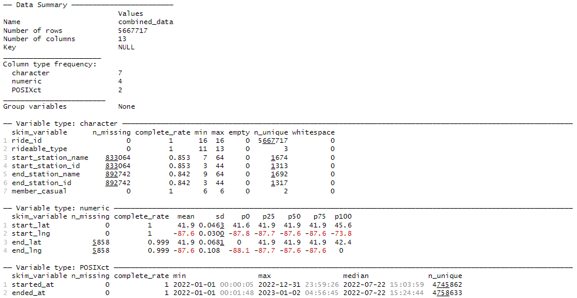

—note: output fungsi ini tidak dapat ditampilkan saat dilakukan export ke HTML dari dokumen R Markdown yang saya gunakan sekarang.

Missing value pada baris yang hilang tidak akan dihapus karena kita akan gunakan informasi pada kolom yang lain pada baris tersebut. Agar tidak terjadi kebingungan dan memberikan kepastian, saya akan menyebut data/ file csv yang sudah digabungkan sebagai **tabel**.

- Lakukan pemeriksaan duplikasi baris pada kolom **`ride_id`** yang menjadi **primary key** pada tabel yang digunakan sedangkan kolom yang identik dengan `ride_id` yaitu kolom `start_station_id` dan `end_station_id` akan diabaikan jika terdapat duplikasi karena kedua kolom tersebut menjadi foreign key pada tabel.

```r
# Menghitung jumlah data yang duplicate pada kolom ride_id
duplicate_count_ride_id <- sum(duplicated(combined_data$ride_id))

# Output
print(paste0("Jumlah data duplicate pada kolom ride_id: ", duplicate_count_ride_id))
```

```
## [1] "Jumlah data duplicate pada kolom ride_id: 0"
```

- Lakukan pemeriksaan apakah ada data yang tidak konsisten pada kolom `started_at` dan `ended_at`; selisih waktu menghasilkan nilai minus atau nol

```r
# Memeriksa konsistensi kolom
inconsistent_data <- combined_data %>%
  filter(started_at >= ended_at | started_at == ended_at)

# Output
if (nrow(inconsistent_data) > 0) {
  print("Terdapat data dengan konsistensi yang tidak sesuai.")
  print(inconsistent_data)
} else {
  print("Semua data dalam kolom waktu datang dan waktu pulang konsisten.")
}
```

```
## [1] "Terdapat data dengan konsistensi yang tidak sesuai."
##               ride_id rideable_type          started_at            ended_at
##   1: C2E047DDF019C255 electric_bike 2022-01-18 19:25:42 2022-01-18 19:25:42
##   2: 8D3E8E511FEB11CC electric_bike 2022-01-21 01:05:35 2022-01-21 01:05:35
##   3: A753A729011B4289 electric_bike 2022-01-09 10:39:48 2022-01-09 10:39:48
##   4: 0C63D14D261205FA electric_bike 2022-01-28 15:28:11 2022-01-28 15:28:11
##   5: 4B0FC5ACEE52EBF9 electric_bike 2022-01-18 19:38:26 2022-01-18 19:38:26
##  ---
## 527: 0D6D8E1FB6361A7F  classic_bike 2022-12-09 17:00:05 2022-12-09 17:00:05
## 528: CE8B25EE8BC25DF2 electric_bike 2022-12-18 11:54:47 2022-12-18 11:54:47
## 529: 1C9AC091E19D9909 electric_bike 2022-12-08 17:05:32 2022-12-08 17:05:32
## 530: 4EEBB6ACBEBE8E80 electric_bike 2022-12-10 13:33:49 2022-12-10 13:33:49
## 531: 3542B0541AA38AB6  classic_bike 2022-12-10 11:59:06 2022-12-10 11:59:06
##                  start_station_name start_station_id          end_station_name
##   1:          Green St & Madison St     TA1307000120                      <NA>
```

[output cut: 22 more lines]

- Terdapat 531 baris yang tidak konsisten, baris tersebut akan dihapus karena butuh validasi lanjutan untuk memperbaiki baris tersebut dengan stakeholder

```r
data_cleaned <- combined_data %>%
  filter(started_at < ended_at, started_at != ended_at)

head(data_cleaned)
```

```
##             ride_id rideable_type          started_at            ended_at
## 1: C2F7DD78E82EC875 electric_bike 2022-01-13 11:59:47 2022-01-13 12:02:44
## 2: A6CF8980A652D272 electric_bike 2022-01-10 08:41:56 2022-01-10 08:46:17
## 3: BD0F91DFF741C66D  classic_bike 2022-01-25 04:53:40 2022-01-25 04:58:01
## 4: CBB80ED419105406  classic_bike 2022-01-04 00:18:04 2022-01-04 00:33:00
## 5: DDC963BFDDA51EEA  classic_bike 2022-01-20 01:31:10 2022-01-20 01:37:12
## 6: A39C6F6CC0586C0B  classic_bike 2022-01-11 18:48:09 2022-01-11 18:51:31
##               start_station_name start_station_id              end_station_name
## 1:      Glenwood Ave & Touhy Ave              525          Clark St & Touhy Ave
## 2:      Glenwood Ave & Touhy Ave              525          Clark St & Touhy Ave
## 3: Sheffield Ave & Fullerton Ave     TA1306000016 Greenview Ave & Fullerton Ave
## 4:      Clark St & Bryn Mawr Ave     KA1504000151     Paulina St & Montrose Ave
## 5:   Michigan Ave & Jackson Blvd     TA1309000002        State St & Randolph St
## 6:         Wood St & Chicago Ave              637       Honore St & Division St
##    end_station_id start_lat start_lng  end_lat   end_lng member_casual
## 1:         RP-007  42.01280 -87.66591 42.01256 -87.67437        casual
## 2:         RP-007  42.01276 -87.66597 42.01256 -87.67437        casual
## 3:   TA1307000001  41.92560 -87.65371 41.92533 -87.66580        member
## 4:   TA1309000021  41.98359 -87.66915 41.96151 -87.67139        casual
## 5:   TA1305000029  41.87785 -87.62408 41.88462 -87.62783        member
## 6:   TA1305000034  41.89563 -87.67207 41.90312 -87.67394        member
```

- cek apakah bisa mencari selisih waktu ketika kolom `started_at` dan `ended_at sudah diperbaiki`

```r
baris_pertama  <- data_cleaned[3, ]
selisih_waktu_ex <- baris_pertama$ended_at - baris_pertama$started_at
print(selisih_waktu_ex)
```

```
## Time difference of 4.35 mins
```

- **Memperbaiki missing value**. Setelah pemeriksaan dan perbaikan selesai pada tiap kolom yang penting pada tabel, saya akan lanjutkan untuk memperbaiki missing value. Pertama, saya akan memisahkan dulu baris yang memiliki nilai NA menjadi tabel tersendiri agar saya dapat dengan mudah memprosesnya.

```r
data_cleaned_na <- data_cleaned %>%
  filter(is.na(start_station_name) | is.na(start_station_id) | is.na(end_station_name) | is.na(end_station_id) | is.na(end_lat) | is.na(end_lng))

str(data_cleaned_na)
```

```
## Classes 'data.table' and 'data.frame':   1298134 obs. of  13 variables:
##  $ ride_id           : chr  "857B71104B437577" "88276B47FFBB9910" "1B66EC28DD618680" "565EEF32A9B65000" ...
##  $ rideable_type     : chr  "electric_bike" "electric_bike" "electric_bike" "electric_bike" ...
##  $ started_at        : POSIXct, format: "2022-01-04 17:08:16" "2022-01-25 07:39:35" ...
##  $ ended_at          : POSIXct, format: "2022-01-04 17:12:15" "2022-01-25 07:41:01" ...
##  $ start_station_name: chr  NA "Larrabee St & Kingsbury St" "Central Park Ave & Ohio St" NA ...
##  $ start_station_id  : chr  NA "TA1306000009" "369" NA ...
##  $ end_station_name  : chr  "Lockwood Ave & Wrightwood Ave" NA NA "Ashland Ave & Grace St" ...
##  $ end_station_id    : chr  "312" NA NA "13319" ...
##  $ start_lat         : num  41.9 41.9 41.9 42 41.9 ...
##  $ start_lng         : num  -87.8 -87.6 -87.7 -87.7 -87.7 ...
##  $ end_lat           : num  41.9 41.9 41.9 42 42 ...
##  $ end_lng           : num  -87.8 -87.6 -87.7 -87.7 -87.7 ...
##  $ member_casual     : chr  "casual" "member" "member" "member" ...
##  - attr(*, ".internal.selfref")=<externalptr>
```

```r
data_cleaned_na
```

```
##                   ride_id rideable_type          started_at            ended_at
##       1: 857B71104B437577 electric_bike 2022-01-04 17:08:16 2022-01-04 17:12:15
##       2: 88276B47FFBB9910 electric_bike 2022-01-25 07:39:35 2022-01-25 07:41:01
##       3: 1B66EC28DD618680 electric_bike 2022-01-21 14:26:57 2022-01-21 14:32:17
##       4: 565EEF32A9B65000 electric_bike 2022-01-11 21:51:25 2022-01-11 21:55:27
##       5: C1C1910260144C76 electric_bike 2022-01-05 03:25:22 2022-01-05 03:43:32
##      ---
## 1298130: A53A821B6A869C19 electric_bike 2022-12-14 19:45:37 2022-12-14 19:56:25
## 1298131: 96AA5A684782CDB9 electric_bike 2022-12-08 14:18:35 2022-12-08 14:28:19
## 1298132: 51BE43187C287458 electric_bike 2022-12-06 07:53:15 2022-12-06 08:01:47
## 1298133: D34CC635D601EC54 electric_bike 2022-12-09 20:27:25 2022-12-09 20:31:31
## 1298134: B6B0A34C3DEAF8E7 electric_bike 2022-12-27 15:36:30 2022-12-27 15:39:49
##                  start_station_name start_station_id
##       1:                       <NA>             <NA>
##       2: Larrabee St & Kingsbury St     TA1306000009
```

[output cut: 33 more lines]

- Mencari missing value pada kolom `start_station_name` dengan cara memisahkan kolom `start_station_name`, `start_lat` dan `start_lng`, kita gunakan informasi yang berada pada kolom `start_lat` dan `start_lng` dengan harapan setian station name memiliki latitude dan longitude yang berpasangan , jika ini cara ini berhasil maka akan dilakukan juga untuk kolom end_station_name.

```r
tabel_distinct_ssn <- data_cleaned_na %>%
  select(start_station_name, start_lat, start_lng) %>%
  distinct(start_lat,start_lng, .keep_all = TRUE)
```

lihat hasil

```r
tabel_distinct_ssn
```

```
##                   start_station_name start_lat start_lng
##      1:                         <NA>  41.93000 -87.76000
##      2:   Larrabee St & Kingsbury St  41.89763 -87.64339
##      3:   Central Park Ave & Ohio St  41.89000 -87.72000
##      4:                         <NA>  41.95000 -87.65000
##      5:                         <NA>  41.92000 -87.69000
##     ---
## 420799:      Wood St & Milwaukee Ave  41.90760 -87.67255
## 420800: Michigan Ave & Washington St  41.88389 -87.62465
## 420801:   Larrabee St & Armitage Ave  41.91813 -87.64377
## 420802:      Dearborn St & Monroe St  41.88053 -87.63000
## 420803:     Hoyne Ave & Balmoral Ave  41.97991 -87.68198
```

Terdapat **1,577 rows** ketika distinct menggunakan nama dan **420,803 rows** ketika distinct menggunakan start_lat dan start_lng

```r
filtered_distinct_ssn <- tabel_distinct_ssn %>%
  filter(grepl("^41.95", start_lat) & grepl("^-87.65", start_lng))

filtered_distinct_ssn
```

```
##                 start_station_name start_lat start_lng
##    1:                         <NA>  41.95000 -87.65000
##    2: Sheridan Rd & Irving Park Rd  41.95420 -87.65445
##    3: Sheridan Rd & Irving Park Rd  41.95430 -87.65443
##    4:          Clark St & Grace St  41.95079 -87.65919
##    5:      Sheridan Rd & Buena Ave  41.95853 -87.65513
##   ---
## 5142:       Broadway & Sheridan Rd  41.95283 -87.65005
## 5143:       Broadway & Sheridan Rd  41.95282 -87.65001
## 5144:       Broadway & Sheridan Rd  41.95279 -87.65010
## 5145:       Broadway & Sheridan Rd  41.95286 -87.65002
## 5146:       Broadway & Sheridan Rd  41.95291 -87.65004
```

Hasilnya **tidak ditemukan** pasangan data pada setiap baris `start_station_name` dengan latitude dan longitudenya. Artinya, pendekatan ini tidak bisa digunakan untuk memperbaiki data yang hilang.

ketika data missing saya akan mencoba untuk mencarinya tetapi jika tidak menemukan data yang dicari, kita bisa langsung tanyakan pada stakeholder/pihak yang terkait untuk mencari tahu apa yang terjadi pada data point ini atau apakah ada sumber data lain yang bisa digunakan. Namun saya tidak punya akses untuk sumber daya seperti ini, jadi saya tetap mempertahankan data yang ada. Dengan sisa data yang ada perhitungan maupun analisa yang dihasilkan akan tetap benar jika mengacu pada *statiscal power*.

- Memperbaiki value agar lebih informatif dan mudah dibaca, seperti yang akan saya lakukan pada kolom `rideable_type` dan `member_casual`

```r
data_cleaned %>%
  select(rideable_type, member_casual) %>%
  distinct(rideable_type, member_casual)
```

```
##    rideable_type member_casual
## 1: electric_bike        casual
## 2:  classic_bike        member
## 3:  classic_bike        casual
## 4: electric_bike        member
## 5:   docked_bike        casual
```

```r
data_cleaned <- data_cleaned %>%
  mutate(rideable_type = case_when(
    rideable_type == "electric_bike" ~ "Electric Bike",
    rideable_type == "classic_bike" ~ "Classic Bike",
    rideable_type == "docked_bike" ~ "Docked Bike",
    TRUE ~ rideable_type  # Jika tidak ada perubahan, biarkan nilai asli
    ),
    member_casual = case_when(
      member_casual == "casual" ~ "Casual Member",
      member_casual == "member" ~ "Annual Member",
      TRUE ~ member_casual
    )
  )
```

- Memisahkan bulan, hari dan jam pada kolom `started_at` dan `ended_at` untuk memahami pola penggunaan sepeda berdasarkan waktu yang lebih spesifik, seperti jam-jam sibuk, hari-hari tertentu, atau perbedaan musiman. Saya gunakan fungsi `mutate()` dari package `diplyr` untuk menambahkan kolom baru dan menggunakan package `lubridate` untuk mengekstrak informasi tentang bulan, hari, serta jam.

```r
data_cleaned <- data_cleaned %>%
  mutate(
    start_month = lubridate::month(started_at),
    start_day = lubridate::day(started_at),
    start_hour = lubridate::hour(started_at),
    end_month = lubridate::month(ended_at),
    end_day = lubridate::day(ended_at),
    end_hour = lubridate::hour(ended_at)
  )
```

Karena `start_month` dan `end_month` nomer bulan bukan nama bulan, saya perlu untuk mengubah value pada kolom `start_month` dan `end_month` menjadi nama bulannya. Saya terapkan juga pada kolom `start_day` dan `end_day`

```r
data_cleaned <- data_cleaned %>%
  mutate(
    start_month = month.name[lubridate::month(started_at)],
    end_month = month.name[lubridate::month(ended_at)]
  )
```

```r
data_cleaned <- data_cleaned %>%
  mutate(
    start_day_of_week = weekdays.Date(started_at),
    end_day_of_week = weekdays(ended_at)
  )
```

```r
data_cleaned <- data_cleaned %>%
  mutate(start_day_of_week = case_when(
    start_day_of_week == "Senin" ~ "Monday",
    start_day_of_week == "Selasa" ~ "Tuesday",
    start_day_of_week == "Rabu" ~ "Wednesday",
    start_day_of_week == "Kamis" ~ "Thursday",
    start_day_of_week == "Jumat" ~ "Friday ",
    start_day_of_week == "Sabtu" ~ "Saturday ",
    start_day_of_week == "Minggu" ~ "Sunday",
    TRUE ~ start_day_of_week  # Jika tidak ada perubahan, biarkan nilai asli
    ),
    end_day_of_week = case_when(
    end_day_of_week == "Senin" ~ "Monday",
    end_day_of_week == "Selasa" ~ "Tuesday",
    end_day_of_week == "Rabu" ~ "Wednesday",
    end_day_of_week == "Kamis" ~ "Thursday",
    end_day_of_week == "Jumat" ~ "Friday ",
    end_day_of_week == "Sabtu" ~ "Saturday ",
    end_day_of_week == "Minggu" ~ "Sunday",
    TRUE ~ end_day_of_week
    )

  )
```

```r
head(data_cleaned)
```

```
##             ride_id rideable_type          started_at            ended_at
## 1: C2F7DD78E82EC875 Electric Bike 2022-01-13 11:59:47 2022-01-13 12:02:44
## 2: A6CF8980A652D272 Electric Bike 2022-01-10 08:41:56 2022-01-10 08:46:17
## 3: BD0F91DFF741C66D  Classic Bike 2022-01-25 04:53:40 2022-01-25 04:58:01
## 4: CBB80ED419105406  Classic Bike 2022-01-04 00:18:04 2022-01-04 00:33:00
## 5: DDC963BFDDA51EEA  Classic Bike 2022-01-20 01:31:10 2022-01-20 01:37:12
## 6: A39C6F6CC0586C0B  Classic Bike 2022-01-11 18:48:09 2022-01-11 18:51:31
##               start_station_name start_station_id              end_station_name
## 1:      Glenwood Ave & Touhy Ave              525          Clark St & Touhy Ave
## 2:      Glenwood Ave & Touhy Ave              525          Clark St & Touhy Ave
## 3: Sheffield Ave & Fullerton Ave     TA1306000016 Greenview Ave & Fullerton Ave
## 4:      Clark St & Bryn Mawr Ave     KA1504000151     Paulina St & Montrose Ave
## 5:   Michigan Ave & Jackson Blvd     TA1309000002        State St & Randolph St
## 6:         Wood St & Chicago Ave              637       Honore St & Division St
##    end_station_id start_lat start_lng  end_lat   end_lng member_casual
```

[output cut: 20 more lines]

```r
dim.data.frame(data_cleaned)
```

```
## [1] 5667186      21
```

Tabel sekarang memiliki **5.667.186 baris** dan **21 kolom** dengan format yang benar. Sekarang data sudah dapat kita proses untuk menjawab tujuan projek!

# Analisa

Sebelum analisa dilakukan, sebaiknya kita perlu memikirkan ulang tujuan projek, tugas bisnis dan ekspektasi pemangku kepentingan

**Tujuan:**

Merancang strategi pemasaran yang bertujuan untuk mengubah anggota biasa menjadi anggota tahunan dan meningkatkat jumlah pengendara tahunan sebanyak 20% selama satu tahun. Hasil akhirnya akan merekomendasikan strategi pemasaran untuk meningkatkan jumlah penumpang tahunan.

**Tugas bisnis:**

Menganalisis data perjalanan sepeda Cyclistic untuk mengidentifikasi trend dan kebiasaan pengendara tahunan maupun pengendara biasa.

Dari tugas bisnis kita mengetahui dua hal yang penting adalah **mengidentifikasi trend dan kebiasaan** pada masing-masing pengendara. Ayo kita gali lebih dalam data yang kita punya, Let’s goo!!!!

### **Identifikasi Trend dan Kebiasaan**

Dari pertanyaan yang sudah dibuat diawal, kita akan mencari **perbedaan setiap hal, karakteristik dan kebiasaan** yang ada pada Annual Member dengan Casual Member

- Jumlah Perjalanan/Pengguna keseluruhan

```r
library(tidyverse)
library(data.table)
library(dplyr)
library(ggplot2)
library(ggthemes)
```

```r
data_per_member <- data_cleaned[,c(.N), by=c("member_casual")]
data_per_member <- data_per_member %>%
  mutate(Persentase = (V1 / sum(V1)) * 100)
```

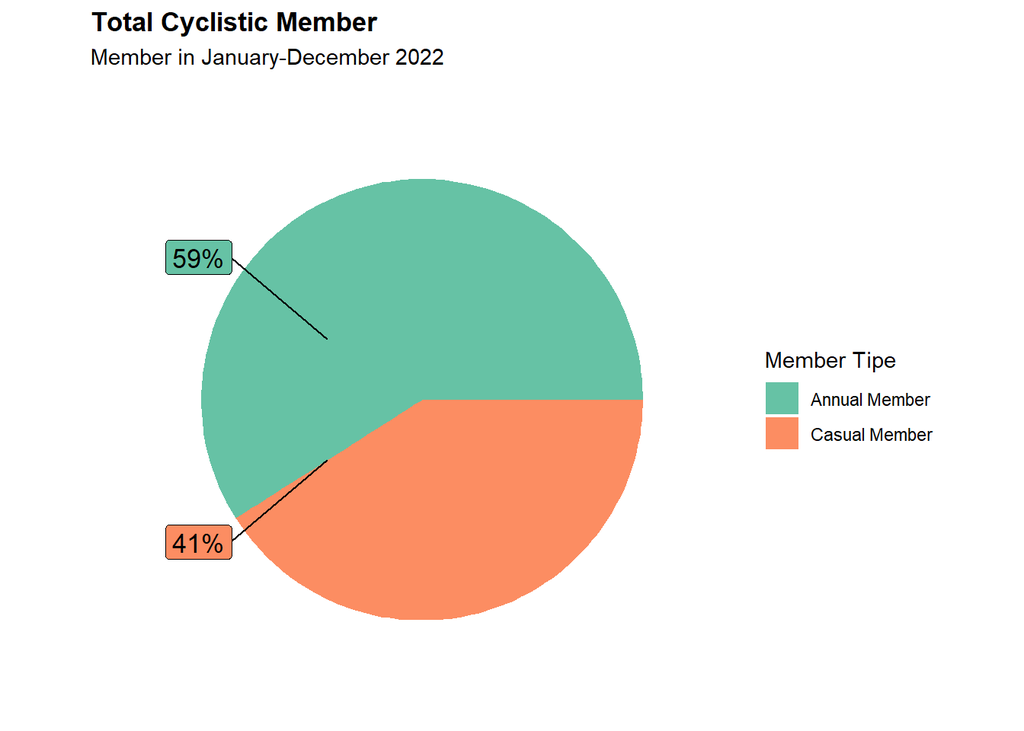

```r
library(RColorBrewer)
library(ggrepel)

palet_warna <- brewer.pal(1, "Set2")
viz_total <- ggplot(data_per_member, aes(x = "", y = V1, fill = member_casual)) +
  geom_col(width = 1) +
  coord_polar(theta = "y", start = pi/2) +
  scale_fill_manual(values = palet_warna) +
  geom_label_repel(data = data_per_member,
    aes(y = V1, label = paste0(round(Persentase, 1), "%")),
    size = 4.5, nudge_x = 0.7, show.legend = FALSE)+
  theme_minimal()+
  theme_void()+
  labs(title = "Total Cyclistic Member",
       subtitle = "Member in January-December 2022",
       fill = guide_legend(title = "Member Tipe")) +
  theme(plot.title = element_text(face ="bold"))

viz_total
```

Jumlah **Annual Member sebanyak 3.345.417 atau 59%** dan jumlah **Casual Member sebanyak 2.321.769 atau 41%**. Tujuan dari projek analisa ini yaitu membuat strategi pemasaran untuk meningkatkan 20% (669.084 anggota) jumlah Annual member selama satu tahun, artinya dalam tiap bulan diharuskan terjadi peningkatan anggota Annual member sebanyak **55.757 anggota.**

- Jumlah Perjalanan/Pengguna per Bulan

```r
data_per_month <- data_cleaned[,c(.N),by=c("start_month","member_casual")]
```

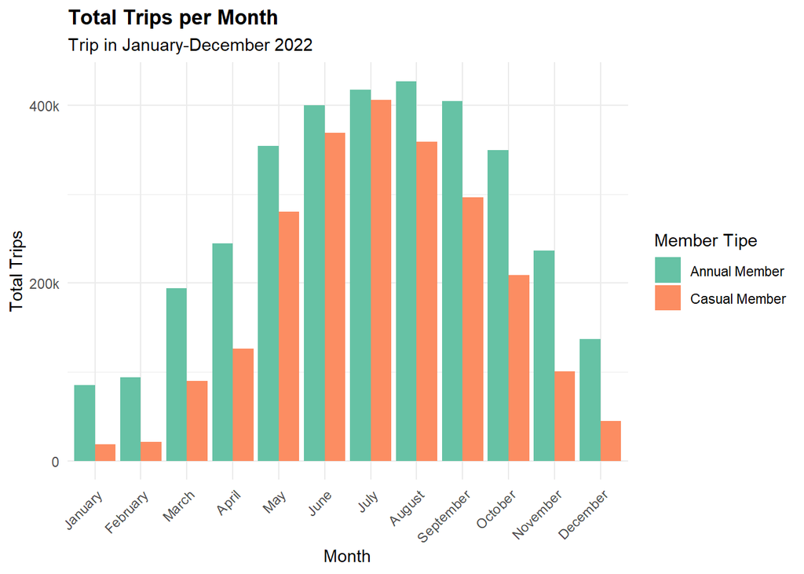

```r
viz_month <- ggplot(data = data_per_month, aes(x=start_month, y = V1, fill=member_casual))+
  geom_bar(stat="identity", position="dodge")+
  scale_fill_manual(values = palet_warna) +
  labs(title ="Total Trips per Month", x="Month", y="Total Trips", fill="Member Tipe", subtitle="Trip in January-December 2022")+
  scale_y_continuous(breaks = c(0,200000, 400000), labels = c("0","200k","400k"))+
  theme_minimal()+
  theme(axis.text.x = element_text(angle = 45, hjust = 1),
        plot.title = element_text(face="bold"))+
  scale_x_discrete(limits = c("January", "February", "March", "April", "May", "June", "July", "August", "September", "October", "November", "December"))

viz_month
```

Mencari nilai rata-rata pada perjalanan bulanan tiap tipe member, data ini akan membantu kita untuk menemukan bulan mana yang memiliki nilai diatas rata-rata agar strategi pemasaran lebih fokus pada bulan tersebut

```r
mean_per_month_am <- data_per_month[member_casual=="Annual Member", mean(V1)]
mean_per_month_cm <- data_per_month[member_casual=="Casual Member", mean(V1)]
mean_per_month_am
```

```
## [1] 278784.8
```

```r
mean_per_month_cm
```

```
## [1] 193480.8
```

Perjalanan/penggunan rata-rata per bulan untuk **Annual Member** sebesar **278.784** dan untuk **Casual Member** sebesar **193.480**

Mencari bulan yang memiliki jumlah perjalanan/pengguna lebih dari rata-rata tiap tipe member

```r
result_mean_am <- data_per_month %>%
  filter(member_casual=="Annual Member") %>%
  filter(V1>mean_per_month_am)

result_mean_am
```

```
##    start_month member_casual     V1
## 1:         May Annual Member 354423
## 2:        June Annual Member 400116
## 3:        July Annual Member 417403
## 4:      August Annual Member 426969
## 5:   September Annual Member 404603
## 6:     October Annual Member 349659
```

```r
result_mean_cm <- data_per_month %>%
  filter(member_casual=="Casual Member") %>%
  filter(V1>mean_per_month_cm)

result_mean_cm
```

```
##    start_month member_casual     V1
## 1:         May Casual Member 280387
## 2:        June Casual Member 369022
## 3:        July Casual Member 406013
## 4:      August Casual Member 358886
## 5:   September Casual Member 296664
## 6:     October Casual Member 208961
```

Bulan yang memiliki jumlah perjalanan/pengguna lebih dari rata-rata tiap tipe member adalah sama, yaitu bulan **Mei, Juni, July, Agustus, September dan Oktober**

Perjalanan/penggunan terbanyak untuk **Annual Member** terjadi pada **Agusutus** sebanyak **426.969** dan perjalanan/penggunan terbanyak untuk **Casul Member** terjadi pada **Juli** sebanyak **406.013.**

Menambahkan nilai rata-rata pada grafik

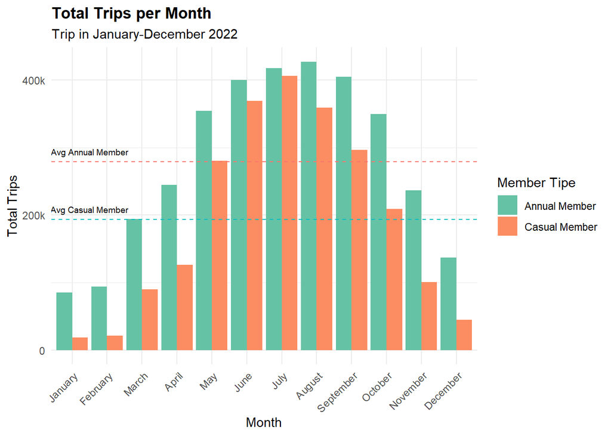

```r
viz_month <- viz_month +
  geom_hline(aes(yintercept = mean_per_month_am, color = "blue"), linetype = "dashed", show.legend = FALSE) +
  geom_hline(aes(yintercept = mean_per_month_cm, color = "red"), linetype = "dashed", show.legend = FALSE) +
  annotate("text", x = 1.5, y = mean_per_month_am, label = paste("Avg Annual Member"),
           vjust = -1, hjust = 0.5, size = 2.5) +
  annotate("text", x = 1.5, y = mean_per_month_cm, label = paste("Avg Casual Member"),
           vjust = -1, hjust = 0.5, size = 2.5)

viz_month
```

```r
ggsave("viz_month.png", viz_month, width = 8, height = 6, units = "in")
```

Jika kita ingin mengetahui alasan kenapa diagram di atas bisa terjadi, kita bisa membandingkan dengan data tentang cuaca, suhu dan musim per tahun. Namun, saya tidak dapat menemukan informasi yang dibutuhkan untuk dilakukan analisa, oleh karena itu saya hanya akan membandingkan dengan visual yang sudah disediakan oleh website https://id.weatherspark.com/.

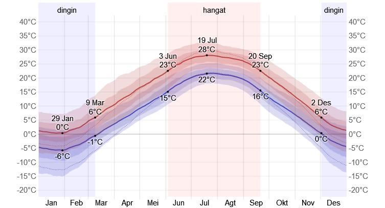

Rata-rata Suhu Tertinggi dan Terdingin di Chicago

Dari diagram yang sudah kita buat dan diagram dari situs https://id.weatherspark.com/ didapatkan bahwa peningkatan jumlah pengguna/perjalanan dipengaruhi oleh suhu dan musim. Pada bulan juni-September di chicago merupakan musim panas/summer.

- Jumlah Perjalanan/Pengguna per Hari

```r
data_per_day <- data_cleaned[,c(.N),by=c("start_day_of_week","member_casual")]
```

```r
viz_day <- ggplot(data = data_per_day, aes(x=start_day_of_week, y = V1, fill=member_casual))+
  geom_bar(stat="identity", position="dodge")+
  scale_fill_manual(values = palet_warna) +
  labs(title ="Total Trips per Day", x="Day", y="Total Trips", fill="Member Tipe", subtitle="Trip in Sunday-Saturday 2022")+
  scale_y_continuous(breaks = c(0,200000, 400000), labels = c("0","200k","400k"))+
  theme_minimal()+
  theme(axis.text.x = element_text(angle = 45, hjust = 1),
        plot.title = element_text(face="bold"))+
  scale_x_discrete(limits = c("Monday", "Tuesday", "Wednesday", "Thursday", "Friday ", "Saturday ", "Sunday"))
```

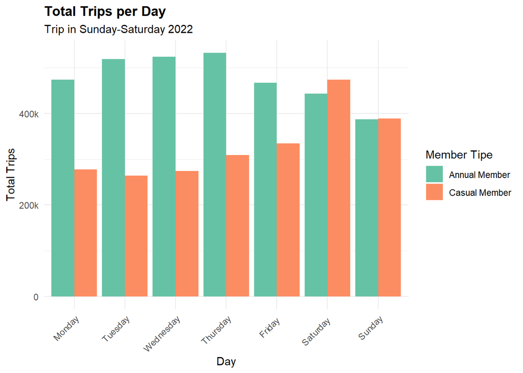

```r
viz_day
```

Mencari nilai rata-rata pada perjalanan harian tiap tipe member, data ini akan membantu kita untuk menemukan hari mana yang memiliki nilai diatas rata-rata agar strategi pemasaran lebih fokus pada hari tersebut

```r
mean_per_day_am <- data_per_day[member_casual=="Annual Member", mean(V1)]
mean_per_day_cm <- data_per_day[member_casual=="Casual Member", mean(V1)]
mean_per_day_am
```

```
## [1] 477916.7
```

```r
mean_per_day_cm
```

```
## [1] 331681.3
```

Perjalanan/penggunan rata-rata per hari untuk **Annual Member** sebesar **477.916** dan untuk **Casual Member** sebesar **331.681**

Mencari bulan yang memiliki jumlah perjalanan/pengguna lebih dari rata-rata tiap tipe member

```r
result_mean_cm_day <- data_per_day %>%
  filter(member_casual=="Casual Member") %>%
  filter(V1>mean_per_day_cm)

result_mean_cm_day
```

```
##    start_day_of_week member_casual     V1
## 1:         Saturday  Casual Member 473130
## 2:           Friday  Casual Member 334667
## 3:            Sunday Casual Member 388981
```

```r
result_mean_am_day <- data_per_day %>%
  filter(member_casual=="Annual Member") %>%
  filter(V1>mean_per_day_am)

result_mean_am_day
```

```
##    start_day_of_week member_casual     V1
## 1:           Tuesday Annual Member 518584
## 2:          Thursday Annual Member 532215
## 3:         Wednesday Annual Member 523836
```

Hari yang memiliki jumlah perjalanan/pengguna lebih dari rata-rata untuk Annual member terjadi pada hari **selasa, rabu dan kamis**, sedangkan pada Casual member terjadi pada hari **jum’at, sabtu dan minggu**. Sesuai dengan tujuan/goal project ini, strategi pemasaran dapat difokuskan pada hari **jum’at, sabtu dan minggu.**

Jika kita perhatikan lebih jauh, Annual member merupakan pengguna yang aktif pada hari weekday dan Casual member merupakan pengguna yang aktif pada weekend. Temuan ini dapat dikembangkan untuk mengetahui apakah Annual member ternyata sekelompok orang yang menggunakan layanan sepeda untuk pergi bekerja dan Casual member ternyara sekelompok orang yang menggunakan layanan sepeda untuk liburan. Kita akan lakukan analisa lebih lanjut untuk memastikan hipotesa ini.

Menambahkan nilai rata-rata pada grafik

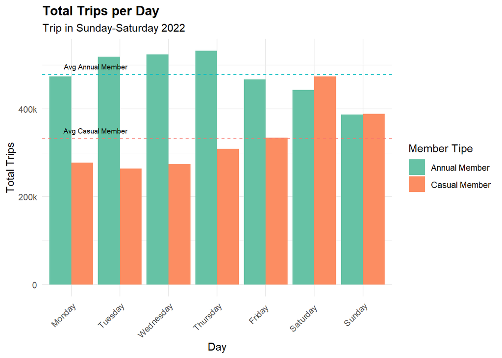

```r
viz_day <- viz_day +
  geom_hline(aes(yintercept = mean_per_day_am, color = "red"), linetype = "dashed", show.legend = FALSE) +
  geom_hline(aes(yintercept = mean_per_day_cm, color = "blue"), linetype = "dashed", show.legend = FALSE) +
  annotate("text", x = 1.5, y = mean_per_day_am, label = paste("Avg Annual Member"),
           vjust = -1, hjust = 0.5, size = 2.5) +
  annotate("text", x = 1.5, y = mean_per_day_cm, label = paste("Avg Casual Member"),
           vjust = -1, hjust = 0.5, size = 2.5)

viz_day
```

- Cek hipotesa mengenai informasi latar belakang tiap member dari letak koordinat station yang digunakan

Kita dapat menggunakan data mengenai lat dan long untuk mencari titik yang sering digunakan untuk tiap member, dari informasi tersebut kita akan mengetahui penggunaan sepeda apakah digunakan untuk bekerja (berada di dalam kota) atau berlibur (berada di sekitar pantai). Karena keterbatasan resource yang saya miliki, saya akan menggunakan data mengenai nama station tiap member.  
Kita akan menggunakan data `end_station_name` karena kita ingin mengetahui daerah tujuan pengguna tiap member

```r
# Mengambil baris dengan kolom start_station_name dan end_station_name tidak null
annual_member_station <- data_cleaned[!is.na(end_station_name) & member_casual == "Annual Member", .(end_station_name)]

annual_member_station <- annual_member_station %>%
  group_by(end_station_name) %>%
  mutate(annual_freq = n()) %>%
  distinct(end_station_name, .keep_all = TRUE) %>%
  arrange(desc(annual_freq))

annual_member_station <- head(annual_member_station, 5)
```

```r
# Mengambil baris dengan kolom start_station_name dan end_station_name tidak null
casual_member_station <- data_cleaned[!is.na(end_station_name) & member_casual == "Casual Member", .(end_station_name)]

casual_member_station <- casual_member_station %>%
  group_by(end_station_name) %>%
  mutate(casual_freq = n()) %>%
  distinct(end_station_name, .keep_all = TRUE) %>%
  arrange(desc(casual_freq))

casual_member_station <- as.data.frame(head(casual_member_station, 5))
```

```r
viz_station_casual <- ggplot() +
  geom_bar(stat="identity", data = casual_member_station, aes(x = casual_freq, y = reorder(end_station_name, casual_freq), fill = "red"))+
  scale_fill_manual(values = palet_warna[2])+
  labs(title = "Top 5 Station Destination", x = "Freq Trip", y = "Station Name", subtitle = "Casual Member")+
  theme_minimal()+
  theme(plot.title = element_text(face = "bold"), legend.position = "none", axis.title.y = element_blank())

viz_station_annual <- ggplot() +
  geom_bar(stat="identity", data = annual_member_station, aes(x = annual_freq, y = reorder(end_station_name, annual_freq), fill = "blue"))+
  scale_fill_manual(values = palet_warna[1])+
  theme_minimal()+
  labs(title = "Top 5 Station Destination", x = "Freq Trip", y = "Station Name", subtitle = "Annual Member")+
  theme(plot.title = element_text(face = "bold"), legend.position = "none", axis.title.y = element_blank())
```

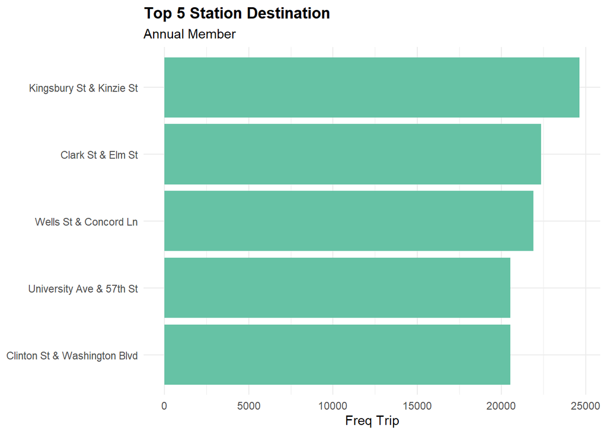

```r
viz_station_annual
```

Dari diagram bar di atas didapatkan 5 teratas stasiun tujuan dari annual member yaitu Kingsbury St & Kinzie St (tengah kota), Clark St & Elm St (tengah kota), Wells St & Concord Ln (dekat taman), University Ave & 57th St (tengah kota) dan Clinton St & Washington Blvd (tengah kota). 4 dari 5 stasiun tujuan teratas yang digunakan oleh annual member berada di tengah kota, temuan ini mendukung hipotesa kita diawal

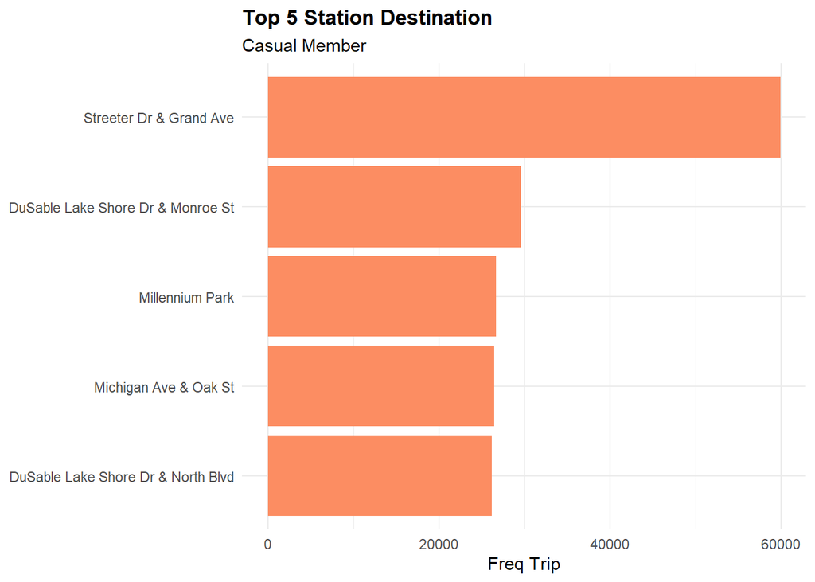

```r
viz_station_casual
```

Karena keterbatasan device/alat yang saya gunakan visual letak tiap stasiun pada map berdasarkan informasi latitude dan longitude tidak dapat dibuat dibuat, oleh karena itu letak tiap stasiun akan dicari secara manual\

Dari diagram bar di atas didapatkan 5 teratas stasiun tujuan dari casual member yaitu Streeter Dr & Grand Ave (dekat pantai), DuSable Lake Shore Dr & Monroe St (dekat pantai), Millennium Park (dekat pantai dan taman), Michigan Ave & Oak St (dekat pantai), dan DuSable Lake Shore Dr & North Blvd (dekat pantai). Semua stasiun tujuan yang digunakan oleh casual member berada di dekat pantai, ini menandakan hipotesa kita benar bahwa **Annual member merupakan seseorang yang menggunakan layanan sepeda untuk keperluan formal seperti bekerja dan Casual member merupakan seseorang yang menggunakan layanan sepeda untuk hiburan dan rekreasi.**

**Dari informasi yang ada, didapatkan kesimpulkan sementara bahwa:**

1. Jumlah Annual member lebih banyak dibandingkan Casual member. Diperlukan 669.084 anggota Annual member baru untuk mencapai tujuan projek yaitu kenaikan 20% dari jumlah Annual member.
2. Bulan yang memiliki jumlah perjalanan/pengguna lebih dari rata-rata tiap tipe member adalah sama, yaitu bulan Mei, Juni, July, Agustus, September dan Oktober. Oleh karena itu, tidak efisien ketika kita membagi strategi pemasaran berdasarkan kuartal per tahun, kita fokuskan pemasran pada bulan-bulan yang memiliki jumlah perjalanan/pengguna lebih dari rata-rata. Perjalanan/penggunan terbanyak untuk Annual Member terjadi pada bulan Agusutus (Late Summer) dan perjalanan/penggunan terbanyak untuk Casual Member terjadi pada bulan Juli (Break Summer).
3. Hari yang memiliki jumlah perjalanan/pengguna lebih dari rata-rata untuk Annual member terjadi pada hari selasa, rabu dan kamis, sedangkan pada Casual member terjadi pada hari jum’at, sabtu dan minggu.
4. Annual member merupakan sekelompok orang yang menggunakan layanan sepeda untuk keperluan formal seperti bekerja dan Casual member merupakan sekelompok orang yang menggunakan layanan sepeda untuk hiburan dan rekreasi.
- Jam perjalanan

```r
data_hour <- data_cleaned[,c(.N), by=c("member_casual", "start_hour")]
```

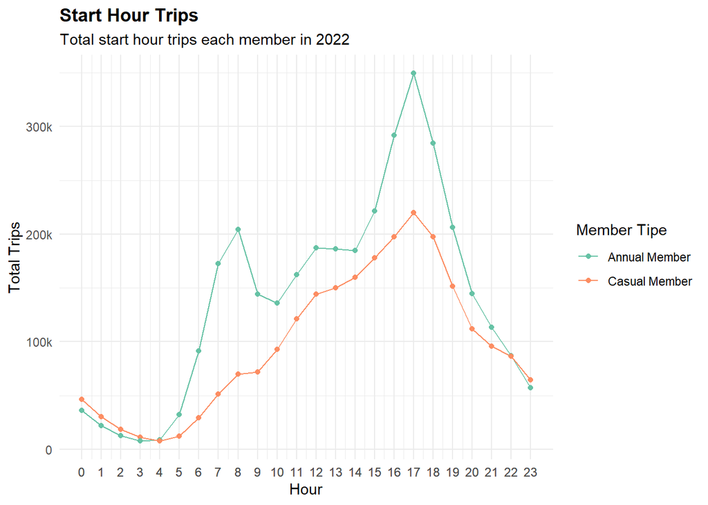

```r
viz_hour <- ggplot(data = data_hour, aes(x= start_hour, y = V1 , color = member_casual))+
  geom_line(aes())+
  geom_point()+
  scale_color_manual(values = c("Casual Member" = "#FC8D62", "Annual Member" ="#66C2A5")) +
  labs(x = "Hour",
       y = "Total Trips",
       title = "Start Hour Trips",
       subtitle = "Total start hour trips each member in 2022",
       color = "Member Tipe")+
  scale_x_continuous(breaks = data_hour$start_hour)+
  theme_minimal()+
  theme(plot.title = element_text(face = "bold"))+
  scale_y_continuous(breaks = c(0,100000, 200000, 300000), labels = c("0","100k","200k", "300k"))

viz_hour
```

Sesuai dengan hipotesa kita diawal bahawa Annual member merupakan sekelompok orang yang menggunakan layanan sepeda untuk keperluan formal seperti berangkat bekerja, karena terjadi peningkatan pengguna signifikan pada jam 05.00 - 08.00 dan 14.00 - 17.00, rentang jam tersebut merupakan waktu yang biasa digunakan untuk berangkt dan pulang bekerja.  
Berbeda dengan penggunaan sepeda oleh Casual member, peningkatan terjadi pada jam 05.00 - 17.00. Fakta ini tidak mendukung hipotesa awal, tapi setidaknya memberikan informai untuk melakukan strategi bisnis (iklan) pada jam tersebut.

- Penggunanaan Tipe sepeda

```r
data_type_ride <- data_cleaned[,c(.N),by=c("rideable_type","member_casual")]
```

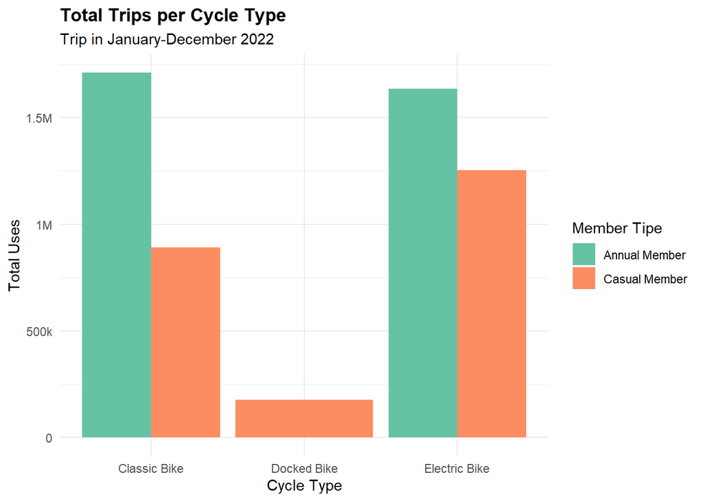

```r
viz_type <- ggplot(data = data_type_ride, aes(x=rideable_type, y = V1, fill=member_casual))+
  geom_bar(stat="identity", position="dodge")+
  scale_fill_manual(values = palet_warna) +
  labs(title ="Total Trips per Cycle Type", x="Cycle Type", y="Total Uses", fill="Member Tipe", subtitle="Trip in January-December 2022")+
  scale_y_continuous(breaks = c(0,500000, 1000000, 1500000), labels = c("0","500k","1M", "1.5M"))+
  theme_minimal()+
  theme(plot.title = element_text(face="bold"))

viz_type
```

Point penting dari diagram di atas bahwa: Tipe sepeda yang paling banya digunakan oleh Annual member adalah merupakan Classic Bike, tidak ada penggunaan tipe sepeda Docked Bike pada Annual member. Ini memberikan kesimpulan yaitu Strategi bisnis yang dibuat tertuju pada tipe sepda Classic Bike dan Electric Bike.

# Berbagi

Dari hasil analisa didapatkan **kesimpulan**:

Kesimpulan yang sudah dibuat dapat menjadi *guideline* untuk tim marketing membuat sebuah strategi pemasaran agar tujuan dapat tercapai

# Bertindak

Pada tahap ini, semua anggota yang terlibat dapat menerapkan dan menjalankan strategi pemasaran yang sudah dibuat dan fokus untuk mencapai tujuan awal.

Terima kasih :)